# Homework 10

Zoe Portlas

October 31, 2018

1. Using a for loop, write a function to calculate the number of zeroes in a numeric vector. Before entering the loop, set up a counter variable counter <- 0. Inside the loop, add 1 to counter each time you have a zero in the matrix. Finally, use return(counter) for the output.

```r
# myVec is a vector of 100 numbers from 0 to 20, rounded down so they're all integers
myVec <- floor(runif(100, min=0, max=21))

# make vector with nothing in it
myCount <- vector("numeric", length = 0)

# make a loop that counts 0s
for(i in seq_along(myVec)){
  if(myVec[i] != 0) next
  myCount <- c(myCount, myVec[i])
}

length(myCount)
```

```
## [1] 6
```

2. Use subsetting instead of a loop to rewrite the function as a single line of code.

```r
# myVec has 100 random integers from range 0-21
myVec <- floor(runif(100, min=0, max=21))

length(myVec[myVec == 0])
```

```
## [1] 6
```

```r
numVec <- runif(10, min = 0, max = 21)

#########################
# FUNCTION: maxDiff
# INPUTS: numeric vector
# OUTPUTS: maximum value of a vector of all possible pairwise differences
#-------------------------
maxDiff <- function(vec = 1:10) {
  vec2 <- dist(vec)
  return(max(vec2))
}
#------------------------

maxDiff(numVec)
```

```
## [1] 19.90165
```

4. Use the code from yesterday’s class to design and conduct a randomization test for some of your own data. You will need to modify the functions that read in the data, calculate the metric, and randomize the data. Once those are set up, the program should run correctly calling your new functions. Also, to make your analysis fully repeatable, make sure you set the random number seed at the beginning (use either set.seed() in base R, or char2seed in the TeachingDemos package

```r
char2seed("Geum")
# function readData
readData <- function(z = NULL){
  if(is.null(z)){
    xObs <- 1:1000
    yObs <- xObs + 10*rnorm(1000)
    dF <- data.frame(ID = seq_along(xObs),
                     xObs,
                     yObs)} else {
  dF <- read.table(file = z, header = TRUE, sep = ",", stringsAsFactors = TRUE)}
  return(dF)
}

# Calculate the metric
getMetric <- function(z=NULL) {
                if(is.null(z)){
                  xObs <- 1:20
                  yObs <-  xObs + 10*rnorm(20)
                  z <- data.frame(ID=seq_along(xObs),xObs,yObs)} # set up data frame
. <- lm(z[,3]~z[,2])
. <- summary(.)
. <- .$coefficients[2,1]

slope <- .
return(slope)
}

# create randomization
shuffleData <- function(z = NULL){
  if(is.null(z)){
  xObs <- 1:20
  yObs <- xObs + 10*rnorm(20)
  z <- data.frame(ID = seq_along(xObs),xObs,yObs)}
  z[,3] <- sample(z[,3])
  return(z)
}

# calculate p value from simulated metrics
getPVAL <- function(z = NULL){
  if(is.null(z)){
    z <- list(xObs = runif(1), xSim = runif(1000))}
  pLower <- mean(z[[2]] <= z[[1]])
  pUpper <- mean(z[[2]] >= z[[1]])
  return(c(pLower,pUpper))
}

# function: plotRanTest
# create ggplot of histogram of simulated values
plotRanTest <- function(z=NULL) {
  if(is.null(z)){
    z <- list(rnorm(1),rnorm(1000)) }
  dF <- data.frame(ID=seq_along(z[[2]]),simX=z[[2]])
  p1 <- ggplot(data=dF,mapping=aes(x=simX))
  p1 + geom_histogram(mapping=aes(fill=I("goldenrod"),color=I("black"))) +
    geom_vline(aes(xintercept=z[[1]],col="blue"))
}

# with randoms (char2seed = "geum")
nSim <- 1000
Xsim <- rep(NA, nSim)
ran <- readData()
head(ran)
```

```
##   ID xObs       yObs
## 1  1    1   1.654527
## 2  2    2 -19.578691
## 3  3    3   1.664164
## 4  4    4  -2.495292
## 5  5    5  16.964929
## 6  6    6   4.204024
```

```r
Xobs <-getMetric(ran)
Xobs
```

```
## [1] 0.9985719
```

```r
for(i in seq_len(nSim)){
  Xsim[i] <- getMetric(shuffleData(ran))
}

slopes <- list(Xobs, Xsim)

getPVAL(slopes)
```

```
## [1] 1 0
```

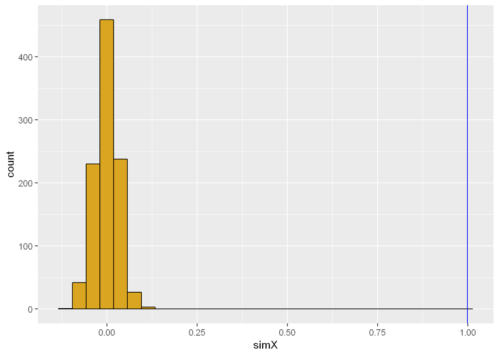

```r
plotRanTest(slopes)
```

```r
# with geum
nSim <- 1000
Xsim <- rep(NA, nSim)
geum <- readData(z = 'DispersalSmall2.csv')
head(geum)
```

```
##   Seq     xObs     yObs
## 1   1 1.511952 6.679147
## 2   2 1.390324 6.276464
## 3   3 1.446029 6.643644
## 4   4 1.517564 6.783583
## 5   5 1.495326 6.582629
## 6   6 1.483577 6.755442
```

```r
Xobs <-getMetric(geum)
Xobs
```

```
## [1] 2.820697
```

```r
for(i in seq_len(nSim)){
  Xsim[i] <- getMetric(shuffleData(geum))
}

slopes <- list(Xobs, Xsim)

getPVAL(slopes)
```

```
## [1] 1 0
```

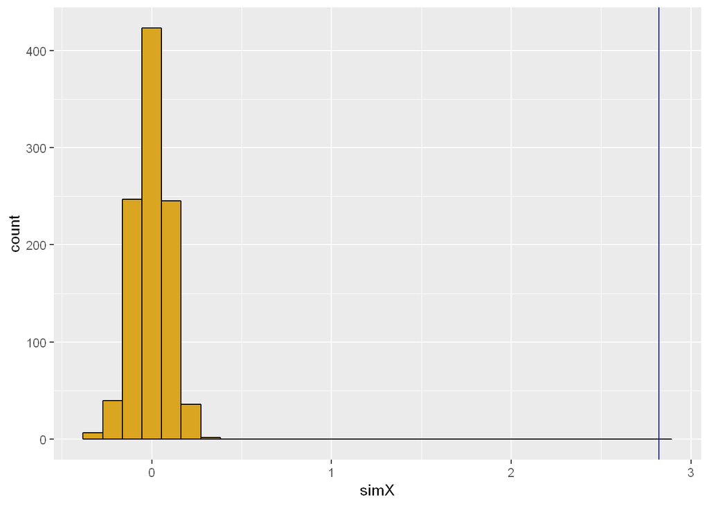

```r
plotRanTest(slopes)
```

5. For comparison, calculate in R the standard statistical analysis you would use with these data. How does the p-value compare for the standard test versus the p value you estimated from your randomization test? If the p values seem very different, run the program again with a different starting seed (and/or increase the number of replications in your randomization test). If there are persistent differences in the p value of the standard test versus your randomization, what do you think is responsible for this difference?

```r
head(geum)
```

```
##   Seq     xObs     yObs
## 1   1 1.511952 6.679147
## 2   2 1.390324 6.276464
## 3   3 1.446029 6.643644
## 4   4 1.517564 6.783583
## 5   5 1.495326 6.582629
## 6   6 1.483577 6.755442
```

```r
geumlm <- lm(geum$yObs~geum$xObs)

summary(geumlm)
```

```
##
## Call:
## lm(formula = geum$yObs ~ geum$xObs)
##
## Residuals:
##     Min      1Q  Median      3Q     Max
## -3.6476 -0.7500 -0.0076  0.7791  2.9721
##
## Coefficients:
##             Estimate Std. Error t value Pr(>|t|)
## (Intercept)  2.54054    0.10566   24.04   <2e-16 ***
## geum$xObs    2.82070    0.07829   36.03   <2e-16 ***
## ---
## Signif. codes:  0 '***' 0.001 '**' 0.01 '*' 0.05 '.' 0.1 ' ' 1
##
## Residual standard error: 1.032 on 2178 degrees of freedom
## Multiple R-squared:  0.3734, Adjusted R-squared:  0.3731
## F-statistic:  1298 on 1 and 2178 DF,  p-value: < 2.2e-16
```

```r
## slope of 2.82 matches and p value of <2.2e-16 matches!
```